# Reproducible Research: Peer Assessment 1

## Loading and preprocessing the data

The language is set at English, the required libraries are read.

```r
library(dplyr)
library(lattice)
Sys.setlocale("LC_ALL", "English")
```

```
## [1] "LC_COLLATE=English_United States.1252;LC_CTYPE=English_United States.1252;LC_MONETARY=English_United States.1252;LC_NUMERIC=C;LC_TIME=English_United States.1252"
```

The data is loaded:

```r
setwd( "C:/Users/corin/Desktop/coursera/course5/week2")

dataset_url <- "https://d396qusza40orc.cloudfront.net/repdata%2Fdata%2Factivity.zip"
download.file(dataset_url, "active.zip")
unzip("active.zip", exdir = "active_data")

data <- read.csv("activity.csv")
```

## What is mean total number of steps taken per day?

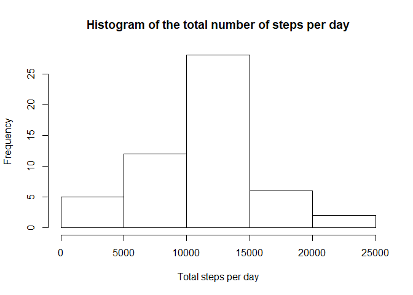

```r
group <- group_by(data, date)
steps_per_day <- summarize(group, sum(steps))
names(steps_per_day)[[2]] <- "total_steps"
hist(steps_per_day$total_steps,
      xlab = "Total steps per day",
      main = "Histogram of the total number of steps per day")
```

```r
dev.copy(png, file = "Daily_steps.png", height = 480, width = 480)
```

```r
dev.off()
```

The mean and median are calculated:

```r
mean(steps_per_day$total_steps, na.rm = TRUE)
```

```
## [1] 10766.19
```

```r
median(steps_per_day$total_steps, na.rm = TRUE)
```

```
## [1] 10765
```

## What is the average daily activity pattern?

The data is grouped by the interval to calculate the daily activity. The plot shows the daily average

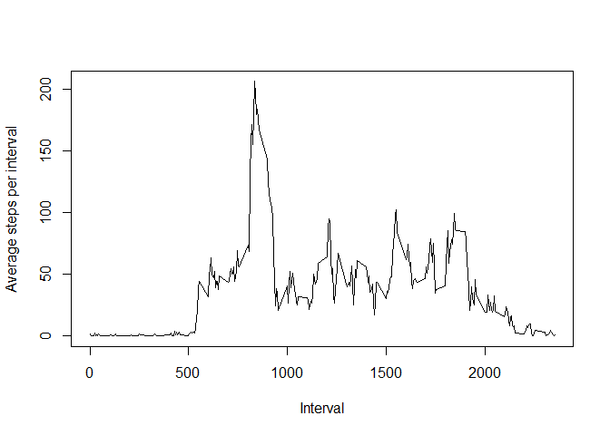

```r
group_time <- group_by(data, interval)
steps_per_interval <- summarize(group_time, mean(steps, na.rm = TRUE))
names(steps_per_interval)[[2]] <- "average_steps"

plot(steps_per_interval$interval,
     steps_per_interval$average_steps,
     type = "l",
     xlab = "Interval",
     ylab = "Average steps per interval")
```

```r
dev.copy(png, file = "Steps_per_interval.png", height = 480, width = 480)
```

```r
dev.off()
```

The interval with the highest average number of steps is:

```r
steps_per_interval[which.max( steps_per_interval$average_steps ),1]
```

```
## # A tibble: 1 x 1
##   interval
##      <int>
## 1      835
```

## Imputing missing values

There are some missing values in the data. The total amount of missing numbers is:

```r
sum(is.na(data$steps))
```

```
## [1] 2304
```

The NA’s will be replaced by the mean of the non-missing numbers:

```r
NAmean <- function(x) replace(x, is.na(x), mean(x, na.rm = TRUE))
data[] <- lapply(data, NAmean)
```

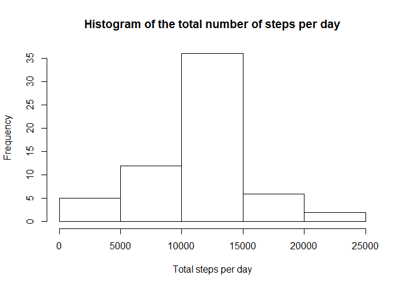

```r
steps_per_day_2 <- tapply(data$steps,data$date,sum)

hist(steps_per_day_2,
     xlab = "Total steps per day",
     main = "Histogram of the total number of steps per day")
```

```r
dev.copy(png, file = "Daily_steps_NA.png", height = 480, width = 480)
```

```r
dev.off()
```

The calculated mean and median of the total number of steps per day:

```r
mean(steps_per_day_2)
```

```
## [1] 10766.19
```

```r
median(steps_per_day_2)
```

```
## [1] 10766.19
```

## Are there differences in activity patterns between weekdays and weekends?

FOr the differences between working days and weekend, the data first is divided into these two categories:

```r
data$date<- as.POSIXct(as.character(data$date))
data$weekday <- weekdays(data$date)

data$day <- ifelse((data$weekday == "Monday" |
                      data$weekday == "Tuesday"|
                      data$weekday == "Wednesday"|
                      data$weekday == "Thursday"|
                      data$weekday == "Friday"),
                    "workday",
                    "weekend")
```

The data is grouped by the days and the interval, to make a plot of the average number of steps in the two categories.

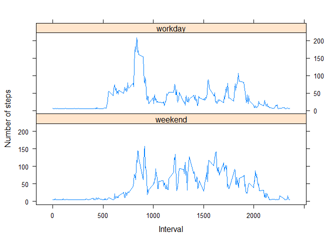

```r
group <- group_by(data, interval)
group2 <- group_by(group, day, add = TRUE)
steps_per_interval <- summarize(group2, mean(steps, na.rm = TRUE))
names(steps_per_interval)[[3]] <- "average_steps"


attach(steps_per_interval)

par(mfrow=c(2,1))
xyplot(average_steps~interval|day,
            xlab="Interval",
            ylab ="Number of steps",
            layout = c(1,2),
            type = "l")
```

```r
dev.copy(png, file = "workday_weekend.png", height = 480, width = 480)
```

```r
dev.off()
```